# HW5_B66043

Dzvezdana Arsovska

March 14, 2017

## Exercise 1

Use the example data and simulate FP-Tree growth algorithm. Report all item sets with support count 3 or more. Report most frequent 3-element item sets and some “most interesting” rules.

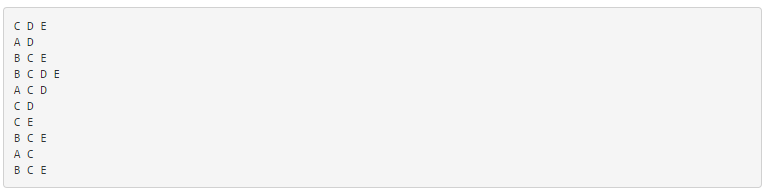

**Solution:**

The FP-Growth Algorithm is an efficient and scalable method for mining the complete set of frequent patterns by pattern fragment growth, using an extended prefix-tree structure for storing compressed and crucial information about frequent patterns named frequent-pattern tree.

The counting of the frequency of the letters in each transaction was done using the following Python code:

```python
# mytext.txt contains all transaction sets;
# counting the number of occurence of C and D in all transactions;

for word in file('mytext.txt').read().split():
    if 'C' in word and 'D':
        print word
```

We can notice that all items have support of $3$ or more. The results of the sorting of the transactions are shown in the following tables:

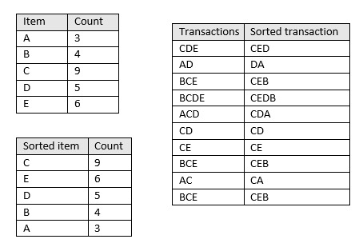

The tree based on the sorted transactions is shown in the following image:

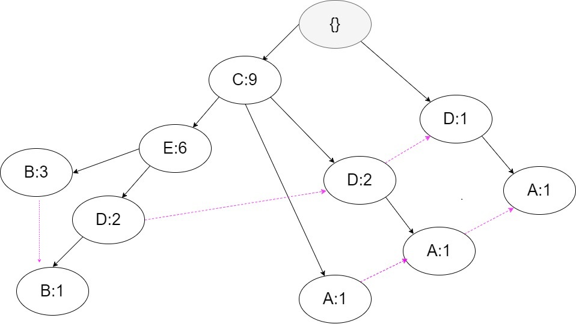

The paths that contain the nodes A,B,C,D and E are shown on the following images:

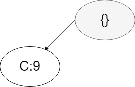

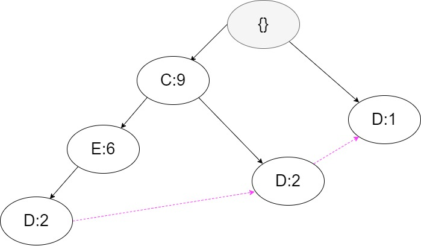

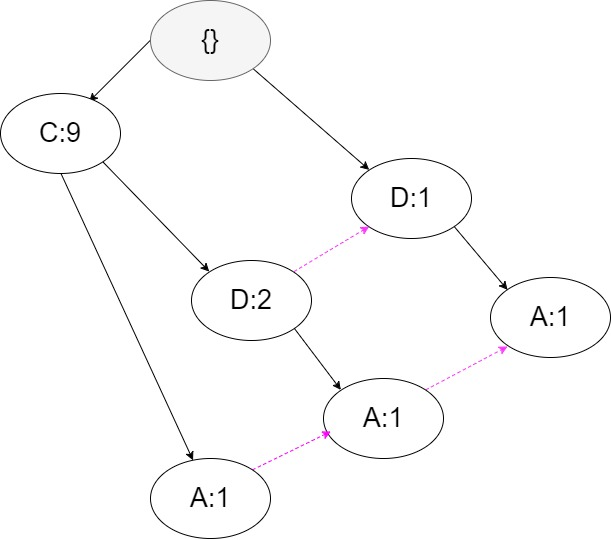

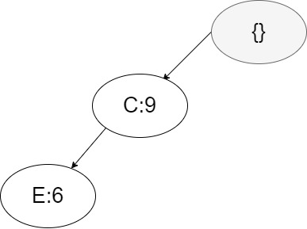

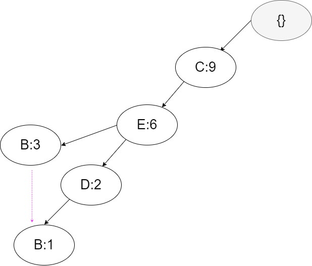

The conditional pattern base and the frequent items sets, based on the tree are:

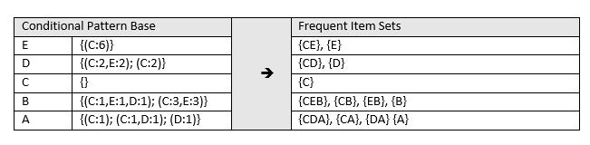

The item set with the highest support is $CE$ with support of $6$. $CD$, $CEB$, $CB$ and $EB$ have support of $4$. $CDA$, $DA$ and $CA$ have support of $1$,$2$ and $2$ respectively and this support is bellow the minimum support of $3$.

## Exercise 2

Make a vertical layout for the same above data for manual inspection. Show how the vertical layout can be used to calculate the 2x2 contingency table for rules like (B C -> E; E C -> B; C -> A). Calculate for these rules the lift, odds ratio and correlation measures.

**Solution:**

The vertical layout for the data set is:

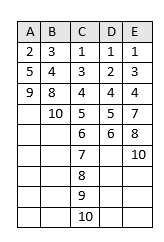

Using the ECLAT algorithm we can determine the support of any k-item set by intersecting tid-lists of two of its (k-1) subsets.

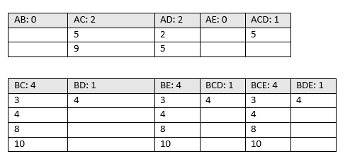

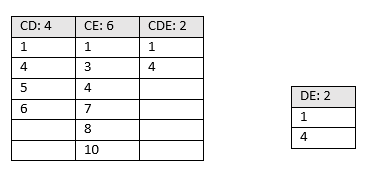

For example we can calculate the values for the lift, the correlation and the odds ratio for the item set $BCE$, which is the only 3 item frequent item set. The results are given in the following tables. In cases were division with 0 occurs, a small number like $0.001$ is added to one of the values in order to avoid getting not defined odds ratio.

[figure not shown]

## Exercise 3

Generate 10,000 random examples of different contingency tables such that in the 2x2 contingency table values are at least 50 in each of the four cells and that all four values add up to 10,000 (i.e. are example 2x2 tables for a database of size 10,000 transactions). Generate the values in the way that only one value of 4 is “small” (between 50-99), any combination of two are “small”, any combination of 3 are “small” and all four are “large”. Try to cover the range of all possible 2x2 values quite evenly. Describe your idea and procedure clearly. And visualize the generated data. Note that fourth value is dependent (10,000 - sum_of_three), so you need to visualize only three values and leave for example the f11 visualized.

**Solution:**

For the generation of the random data I am using the sample function in R which generates random numbers from the range between $1$ and $10000$. The random numbers are normalized and multiplied by $10000$ so their sum is set to be exactly $10000$.

```r
props2 <- function(nrow, ncol) {
    p <- function(n) {
        x1 <- sample(1:10000, ncol)
        vec <- round((x1/sum(x1)) * 10000)
        if (sum(vec) != 10000) {
            o <- diff(c(10000, sum(vec)))
            vec[which.max(vec)] <- max(vec) - o
        }
        return(vec)
    }
    DF <- data.frame(t(replicate(nrow, p(n = ncol))))
    return(DF)
}
```

We can check if the function is working first by inspecting the first $10$ rows of the data set.

```r
DF <- props2(10000, 4)
DF <- transform(DF, sum = rowSums(DF))
colnames(DF) <- c("X1", "notX1", "X2", "notX2", "sum")
head(DF, 10)
```

```
##      X1 notX1   X2 notX2   sum
## 1  3618  2672 1870  1840 10000
## 2  2744  1944 2172  3140 10000
## 3  4370   358  482  4790 10000
## 4  4963   738  661  3638 10000
## 5  1016   604 4830  3550 10000
## 6  3841   398 2999  2762 10000
## 7  4161   282 4187  1370 10000
## 8  4544   146 3057  2253 10000
## 9  3155  3196  953  2696 10000
## 10 1869  3276 3855  1000 10000
```

Also we can print the table of counts for sum and we can see that we have $10000$ rows with sum of $10000$.

```r
table(DF$sum)
```

```
##
## 10000
## 10000
```

In order to check the number of generated small numbers we can create a subset of them using the function subset and print their number.

```r
small <- subset(DF, X1 >= 50 & X1 <= 99 | X2 >= 50 & X2 <= 99 | notX1 >= 50 &
    notX1 <= 99 | notX2 >= 50 & notX2 <= 99)
nrow(small)
```

```
## [1] 300
```

We can also visualize the distribution of the values using a histogram. We can notice that all variables follow positively skewed distribution.

```r
hist(DF$X1, breaks = 100)
```

```r
hist(DF$X2, breaks = 100)
```

```r
hist(DF$notX1, breaks = 100)
```

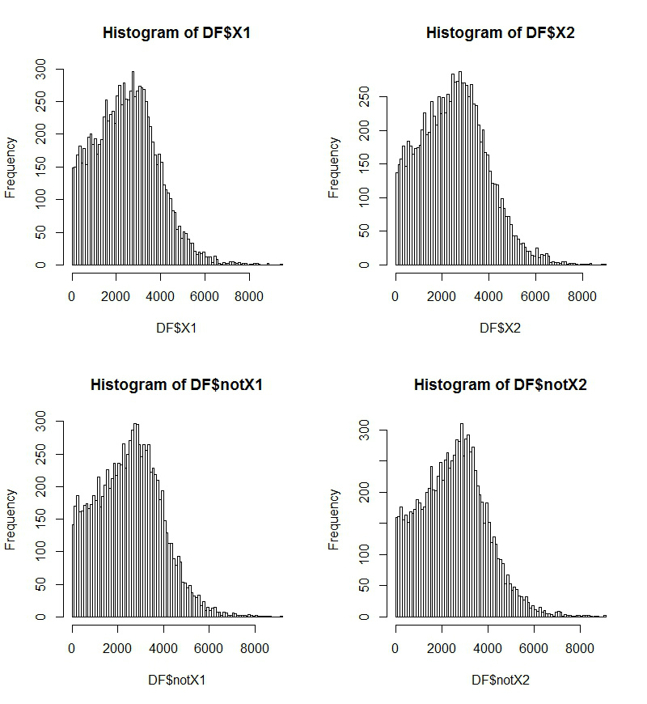

```r
hist(DF$notX2, breaks = 100)
```

Since the fourth column is depended from the previous $3$ we can plot $3$ columns using 3D scatterplot. For this purpose I am using $2$ libraries scatterplot3D and rgl. 3D plots are hard to understand and we can understand the distribution only if we change the angle of view several times.Although this is possible with scatterplot3D is much easier to find a better angle if we use rgl. Using rgl it is possible to create 3D interactive scatterplot that can be rotated for better inspection of the distribution.

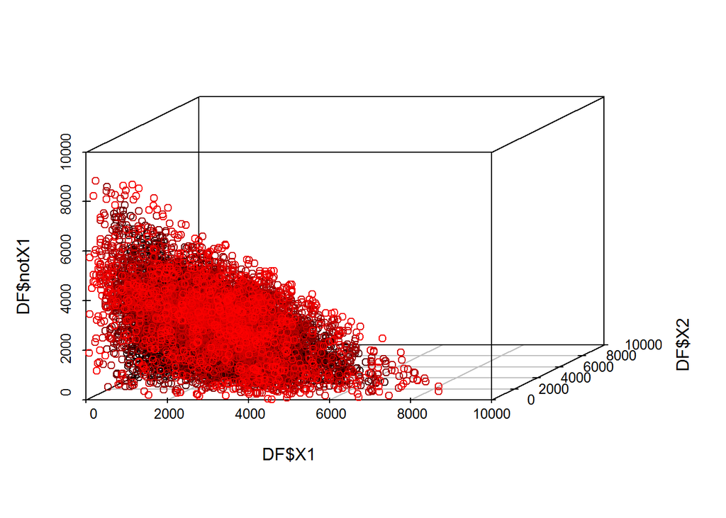

```r
library(scatterplot3d)
scatterplot3d(DF$X1, DF$X2, DF$notX1, highlight.3d = T, angle = 40, scale.y = 0.5)
```

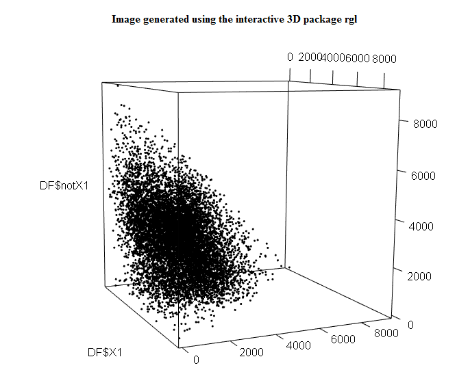

```r
library(rgl)
# plot3d(DF$X1,DF$X2,DF$notX1)
```

## Exercise 4

Based on this synthetic data identify three best examples using lift, odds ratio and correlation measures. Explain them - what would the corresponding rules mean in the sense of supermarket shopping basket analysis (provide some scenario and example based on that).

**Solution:**

```r
# Add odds ratio column
for (i in 1:nrow(DF)) {
    row <- DF[i, ]
    odds = round((DF[, 1] * DF[, 4])/(DF[, 2] * DF[, 3]))
    DF$odds = odds
}

# Add correlation column
for (i in 1:nrow(DF)) {
    row <- DF[i, ]
    phi = (DF[, 1] * DF[, 4])/(DF[, 2] * DF[, 3])/(sqrt(10000 * 10000))
    DF$phi = phi
}

# Add lift value for the rule X2 -> X1;
for (i in 1:nrow(DF)) {
    row <- DF[i, ]
    liftX2_X1 = (10000 * DF[, 1])/((DF[, 1] + DF[, 2]) * (DF[, 1] + DF[, 3]))
    DF$liftX2_X1 = liftX2_X1
}

# Add lift value for the rule X2 -> nX1; Similarly is done for the remaining
# two rules;
for (i in 1:nrow(DF)) {
    row <- DF[i, ]
    liftX2_nX1 = (10000 * DF[, 2])/((DF[, 1] + DF[, 2]) * (DF[, 2] + DF[, 4]))
    DF$liftX2_nX1 = liftX2_nX1
}
```

The first $10$ rows after the columns were added have the following form:

[figure not shown]

We can sort the data using the following function:

```r
DF <- data.frame(lapply(DF, sort, decreasing = T))
```

We can choose to analyse the first $3$ rules.

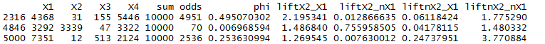

If we imagine that the random generated numbers represent the sales of milk and beer we can construct the following contingency tables:

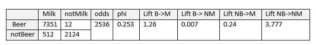

Odds is an expression of probability for binary outcomes. Using the values we obtained using R We can notice that this rule has high odds ratio which implies a strong positive relationship between the sales of the beer and the milk. The value for the correlation coefficient is $0.253$ which implies that we have little or no correlation at all between the sales of the beer and the milk. The rule with the highest lift values is notBeer -> notMilk.

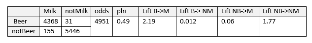

The highest values for the correlation coefficient in this rules is $0.49$ which implies weak positive correlation between the sales of the beer and the milk in the rule. The odds ration also has a high value. The rule with highest lift value is Beer -> Milk which means that people who by beer are also likely to buy milk.

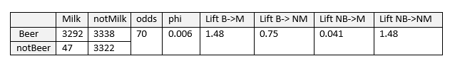

This rule has very low value for the correlation which means that in this case we have little or no correlation at all between the sales of the beer and the milk. The odds ration has much smaller value compared to the previous two rules. The rule with the highest lift is Beer -> Milk.

## Exercise 5

Use the “Titanic” data set and find rules with highest odds ratio. Explain the odds ratio, the found rule and make a comparison to lift. Are there examples where lift and odds ratio give different “best” rules?

**Solution:**

We can group the features in the Titanic data set using the function which. After that we can form the contingency tables and calculate the values for the lift and the odds ratio.

```r
library(data.table)
data <- fread("C:/Users/arsov/OneDrive/Documents/titanic-txt.csv")

MS <- subset(data, Sex == "Male" & Survived == "Yes", select = c(Sex, Survived))
MNS <- subset(data, Sex == "Male" & Survived == "No", select = c(Sex, Survived))

FS <- subset(data, Sex == "Female" & Survived == "Yes", select = c(Sex, Survived))
FNS <- subset(data, Sex == "Female" & Survived == "No", select = c(Sex, Survived))
```

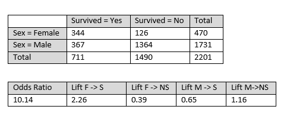

For this contingency table the highest lift ratio is for the rule Female -> Survive and we have odds ratio with value of $10$, which implies that female passengers were more likely to survive then male passengers. If were compare the value of the odds ratio with the lift values we can see that they are showing the same thing.

```r
CS <- subset(data, Age == "Child" & Survived == "Yes", select = c(Age, Survived))
CNS <- subset(data, Age == "Child" & Survived == "No", select = c(Age, Survived))

AS <- subset(data, Age == "Adult" & Survived == "Yes", select = c(Sex, Survived))
ANS <- subset(data, Age == "Adult" & Survived == "No", select = c(Sex, Survived))
```

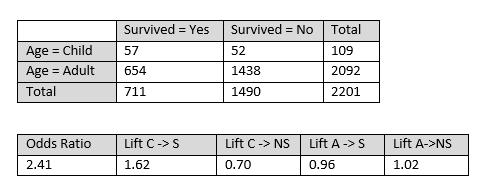

For this contingency table the highest lift ratio is for the rule Child -> Survive and we have odds ratio with value of $2.41$, which implies that children were more likely to survive then adults. If were compare the value of the odds ratio with the lift values we can see that they are showing the same thing for this particular rule.

## Exercise 6

Describe the measure Mutual Information. Report the rules with highest mutual information from synthetic data (3) and the Titanic data sets. Which association rules would have highest mutual information?

**Solution:**

Mutual information is one of many quantities that measures how much one random variables tells us about another. It is a dimensionless quantity with (generally) units of bits, and can be thought of as the reduction in uncertainty about one random variable given knowledge of another. High mutual information indicates a large reduction in uncertainty; low mutual information indicates a small reduction; and zero mutual information between two random variables means the variables are independent. Mutual information is a symmetric quantity.

The most common unit for MI is bits. In that case we measure show many bits will we need in order to store the outcomes Y given that you know the value of X. We can calculate the mutual information in bits using:

```r
library(entropy)

# MI for the rules in the synthetic data
y1d = rbind(c(4368, 31), c(15, 5446))
mi1 = mi.empirical(y1d, unit = c("log2"))
mi1
```

```
## [1] 0.9489707
```

```r
y2d = rbind(c(7351, 12), c(513, 2124))
mi2 = mi.empirical(y2d, unit = c("log2"))
mi2
```

```
## [1] 0.548008
```

```r
y3d = rbind(c(3292, 3339), c(47, 3322))
mi3 = mi.empirical(y3d, unit = c("log2"))
mi3
```

```
## [1] 0.2200838
```

If we find the mutual information for the Titanic data set rules:

```r
t1d = rbind(c(344, 126), c(367, 1364))
mi_t1 = mi.empirical(t1d, unit = c("log2"))
mi_t1
```

```
## [1] 0.1423912
```

```r
t2d = rbind(c(57, 52), c(654, 1438))
mi_t2 = mi.empirical(t2d, unit = c("log2"))
mi_t2
```

```
## [1] 0.006410718
```